# Weather Station Report

Yanal Kashou - HTU

November 22, 2017

## The Data

Our weather station at **HTU** produces hourly weather data. The following table shows the last 3 rows of the dataframe, which are the 3 latest observations made by the weather station.

There is some data preparation to be done:

- The *Date and Time* column must be formatted correctly.
- The *Date* and *Time* columns are redundant and instead we will create our own *Date* and *Time* columns by stripping our formatted *Date and Time* column.
- Columns 12, 13 and 14 should be dropped as they simply represent system-specific units and will have no value in our analysis.
- The *Record* column is simply an index and will also be dropped.
- We will also rename all columns to present them legibly.

|  | DT | Wind.Speed | Wind.Direction.Degree | Wind.Direction. std | Solar.Rad |
| --- | --- | --- | --- | --- | --- |
| 407 | 2017-11-22 14:00:00 | 3.393 | 174.5 | 62.74 | 0.168 |
| 408 | 2017-11-22 14:59:59 | 3.099 | 237.3 | 45.41 | 0.177 |
| 409 | 2017-11-22 16:00:00 | 3.167 | 219.5 | 49.30 | 0.175 |

|  | Air.Temp | Relative.Humidity | Rain.Fall | Visibility | Bar.Pressure |
| --- | --- | --- | --- | --- | --- |
| 407 | 8.77 | 97.2 | 2.286 | 951 | 450.2 |
| 408 | 8.56 | 95.4 | 2.286 | 7906 | 450.3 |
| 409 | 8.86 | 92.9 | 0.508 | 19386 | 450.3 |

## Discovering Correlations

### Correlations Between Features

This is done to discover correlations between the features that the station collected.

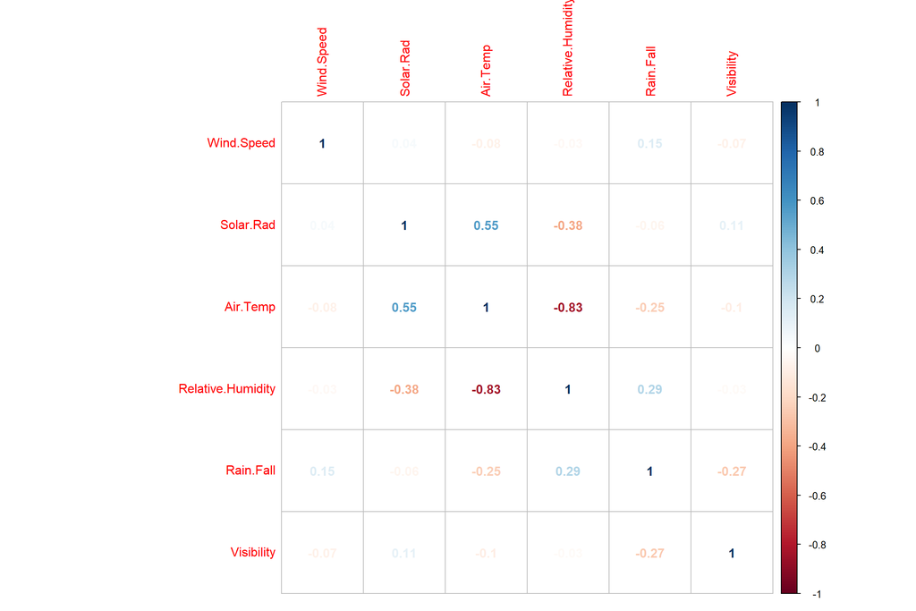

There are some correlations in our data, specifically we can see that *Air Temperature* has the highest positive correlation with *Solar Radiation*, we also see that *Relative Humidity* has the highest negative correlation with *Air Temperature*, which is logical to deduce.

### Correlations with Time

In the previous section, we discovered some direct correlations between features, however, there is no indication of high correlations of any variable with *Visibility*. We would need to take a deeper exploratory look into the data, specifically in the time-domain, to see if there are indeed any hidden or indirect correlations.

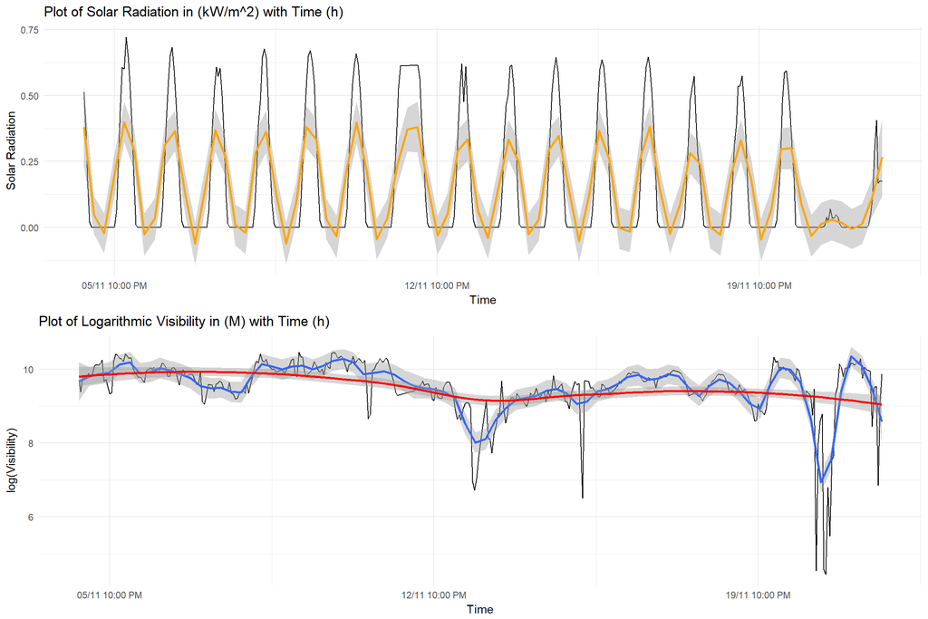

## Sustained Wind Speeds

As above with the temporal plots, we can use the logarithm of the `Wind.Speed` plotted against `Time`, along with different regression lines with 25% (blue), 50% (purple), and 75% (black) of the data to capture a trend.

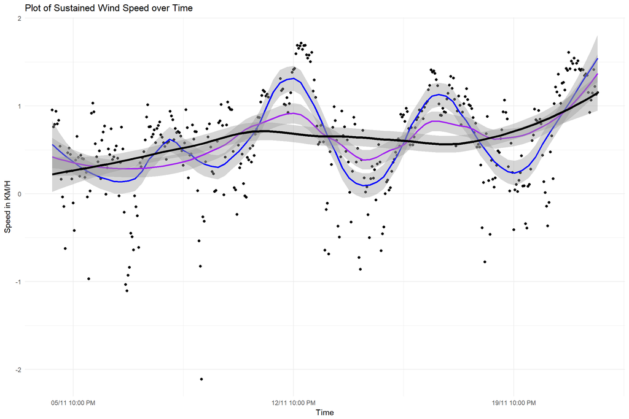

## General Wind Direction

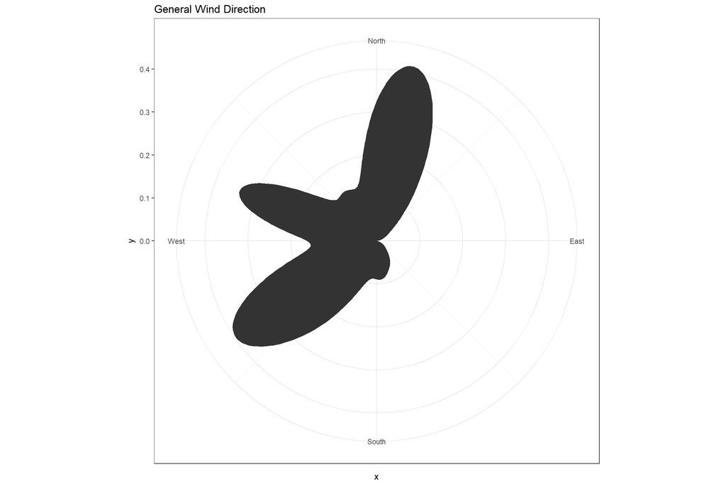

We can deduce from this awkward looking plot that most of the wind either blew from the north or from the south-west, while some of the wind can be attributed to the north-west.